# Assignment 1: Task 1

Jessica Jagdeo

1/24/2020

From 1999 to 2017, physical characteristics of snowshoe hares were observed and recorded in the Bonanza Creek Experimental Forest within Alaska (Kielland et al. 2017). This project utilizes the data obtained from this study to visualize the weight and sex of the observed snowshoe hares. In addition, this project explores the summary statistics of the recorded weights for both female and male snowshoe hares.

#### 1. Load necessary packages.

```r
library(tidyverse)
library(janitor)
library(kableExtra)
library(naniar)
library(skimr)
library(sf)
library(tmap)
```

#### 2. Read in the data: Snowshoe hare physical data in Bonanza Creek Experimental Forest: 1999-Present.

```r
snowshoe <- read_csv("showshoe_lter.csv") %>%
  select(date, sex, age, weight, hindft)

summary(snowshoe) # Determine if there are missing data: 535 NAs in weight column; 1747 NAs in weight column
```

```
##      date               sex                age                weight
##  Length:3380        Length:3380        Length:3380        Min.   :   0
##  Class :character   Class :character   Class :character   1st Qu.:1180
##  Mode  :character   Mode  :character   Mode  :character   Median :1400
##                                                           Mean   :1346
##                                                           3rd Qu.:1580
##                                                           Max.   :2365
##                                                           NA's   :535
##      hindft
##  Min.   : 60.0
##  1st Qu.:128.0
##  Median :135.0
##  Mean   :130.9
##  3rd Qu.:140.0
##  Max.   :160.0
##  NA's   :1747
```

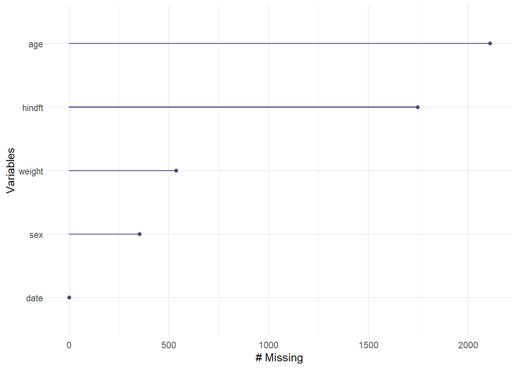

```r
gg_miss_var(snowshoe) # Visualize missing data: Over 2000 observations are missing an age
```

#### 3. Clean the data based on NAs and and confirmed characteristics.

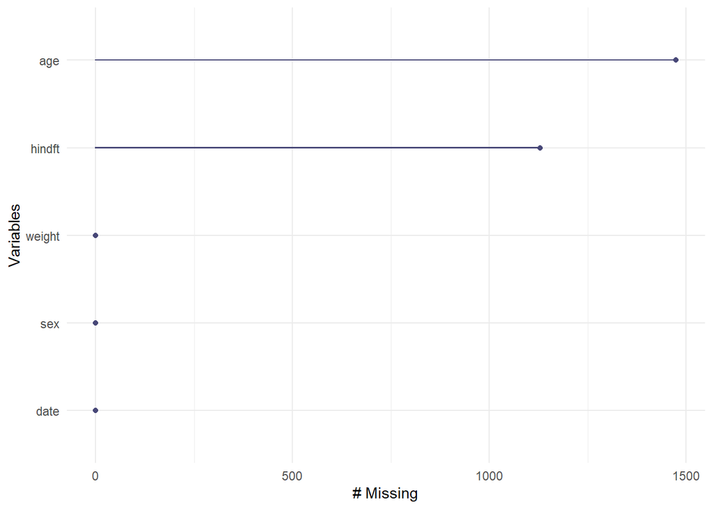

```r
snowshoe_clean <- snowshoe %>%
  drop_na(weight) %>% # There are 500 missing weights out of over 3000 observations, a relatively small portion of total observations, so we can drop the observations without recorded weights
  mutate(sex = str_to_upper(sex)) %>% # Capitalizing characters for aesthetics
  mutate(age = str_to_upper(age)) %>% # Capitalizing characters for aesthetics
  filter(sex == "M" |
           sex == "F") # Only keeping observations in which sex was confirmed (only reduces our number of observations by 200)

snowshoe_clean$sex <- plyr::revalue(snowshoe_clean$sex, c("F" = "Female", "M" = "Male")) # Renaming "F" and "M" to "Female" and "Male", respectively for visualization


gg_miss_var(snowshoe_clean) # Rechecking NAs - none for the weight column
```

#### 4. Graph characteristics of observed snowshoe hares.

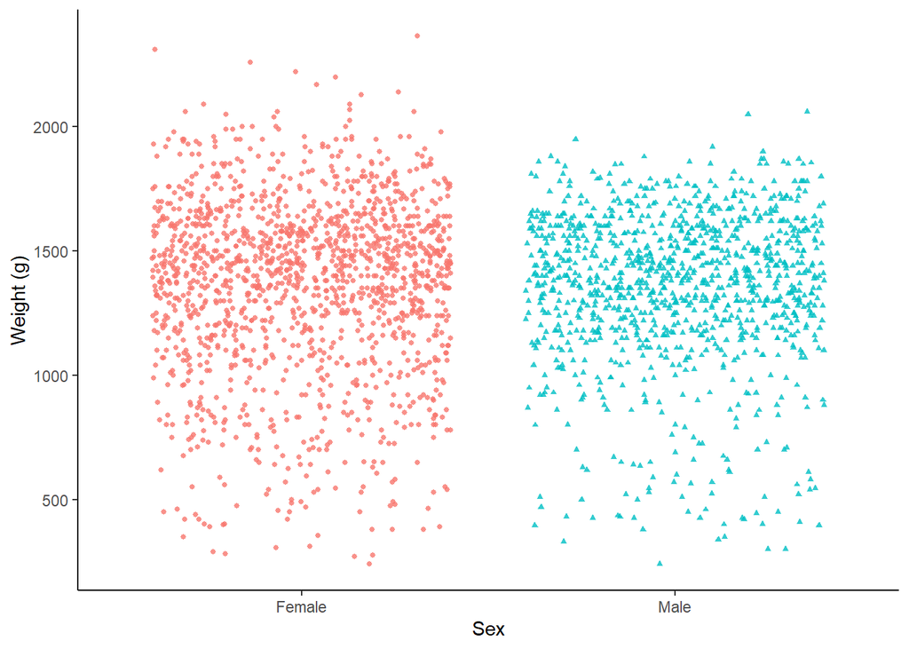

```r
# Creating a jitter plot to depict the weights (y axis) of both female and male snowshoe hares (x axis)

snowshoe_plot <- ggplot(snowshoe_clean,
                        aes(x = sex, y = weight)) +
  geom_jitter(size = 1,
              alpha = 0.8,
              aes(color = sex,
                  pch = sex)) +
  theme_classic() +
  labs(x = "Sex",
       y = "Weight (g)") +
  theme(legend.position = "none")

snowshoe_plot
```

**Figure 1. Characteristics of Observed Snowshoe Hares at Bonanza Creek Experimental Forest.** Recordings of snowshoe hare sex and weight were made during the period of 1999 to 2017. Observations in which both sex and weight were conclusively recorded are depicted. Data source: Kielland et al. 2017.

#### 5. Create kable table with summary statistics about observed snowshoe hare sex and weight.

```r
# Creating a data frame with summary statistics (mean, standard deviation, maximum, minimum, and median) for the weights of female and male snowshoe hares

snowshoe_summary <- snowshoe_clean %>%
  select(sex, weight) %>%
  group_by(sex) %>%
  summarise(
    average_weight = round(mean(weight),0),
    sd_weight = round(sd(weight),0),
    max_weight = max(weight),
    min_weight = min(weight),
    median_weight = median(weight)
  )

snowshoe_table <- kable(snowshoe_summary,
                         caption = "**Table 1. Summary statistics for the weights of female and male snowshoe hares observed in the Bonanza Creek Experimental Forest from 1999 to 2017.** Weights were recorded during capture-recapture studies, with a total of 2,628 complete observations obtained for sex and weight. Data source: Kielland et al. 2017.",
                        col.names = c("Sex", "Mean (g)", "Standard Deviation (g)", "Maximum (g)", "Minimum (g)", "Median (g)")) %>%
  kable_styling(bootstrap_options = c("striped","hover", "condensed")) %>%
  column_spec(1, bold = T, border_right = T)


snowshoe_table
```

**Table 1. Summary statistics for the weights of female and male snowshoe hares observed in the Bonanza Creek Experimental Forest from 1999 to 2017.** Weights were recorded during capture-recapture studies, with a total of 2,628 complete observations obtained for sex and weight. Data source: Kielland et al. 2017.

| Sex | Mean (g) | Standard Deviation (g) | Maximum (g) | Minimum (g) | Median (g) |
| --- | --- | --- | --- | --- | --- |
| Female | 1365 | 347 | 2365 | 240 | 1420 |
| Male | 1350 | 306 | 2060 | 240 | 1390 |

#### 6. Create a map of the study location.

```r
# Creating a data frame with the 3 coordinates of the study sites within Bonanza Creek Experimental Forest

sites <- tribble(
  ~id, ~lon, ~lat,
  "bonrip", -148.2682, 64.6991,
  "bonmat", -148.1734, 64.41417,
  "bonbs", -148.2964, 64.7088
)

# Converting this data frame to "sf" object for visualization within a map

sites_sf <- st_as_sf(sites, coords = c("lon", "lat"), crs = 4269)

# Visualize site locations within an interactive map

tmap_mode("view")

sampling_sites <- tm_basemap("Esri.WorldImagery") +
  tm_shape(sites_sf) +
  tm_dots(labels = "id", col = "darkblue", size = 0.3)

sampling_sites
```

[interactive chart not shown]

**Figure 2. Location of Bonanza Creek Experimental Forest.** Snowshoe hares were observed at three different sites within the forest.

Study citation: Kielland K., F. S. Chapin, R. W. Ruess. 2017. Snowshoe hare physical data in Bonanza Creek Experimental Forest: 1999-Present. Environmental Data Initiative.